# **Problem Statement**

## **Business Context**

Workplace safety in hazardous environments like construction sites and industrial plants is crucial to prevent accidents and injuries. One of the most important safety measures is ensuring workers wear safety helmets, which protect against head injuries from falling objects and machinery. Non-compliance with helmet regulations increases the risk of serious injuries or fatalities, making effective monitoring essential, especially in large-scale operations where manual oversight is prone to errors and inefficiency.

To overcome these challenges, SafeGuard Corp plans to develop an automated image analysis system capable of detecting whether workers are wearing safety helmets. This system will improve safety enforcement, ensuring compliance and reducing the risk of head injuries. By automating helmet monitoring, SafeGuard aims to enhance efficiency, scalability, and accuracy, ultimately fostering a safer work environment while minimizing human error in safety oversight.

## **Objective**

As a data scientist at SafeGuard Corp, you are tasked with developing an image classification model that classifies images into one of two categories:

- **With Helmet:** Workers wearing safety helmets.
- **Without Helmet:** Workers not wearing safety helmets.

## **Data Description**

- **With Helmet:** 311 images showing workers wearing helmets.
- **Without Helmet:** 320 images showing workers not wearing helmets.

**Dataset Characteristics:**

- **Variations in Conditions:** Images include diverse environments such as construction sites, factories, and industrial settings, with variations in lighting, angles, and worker postures to simulate real-world conditions.
- **Worker Activities:** Workers are depicted in different actions such as standing, using tools, or moving, ensuring robust model learning for various scenarios.

# **Installing and Importing the Necessary Libraries**

```python
!pip install tensorflow[and-cuda] numpy==2.0.2 -q
```

[output not shown]

```python
import tensorflow as tf
print("Num GPUs Available:", len(tf.config.list_physical_devices('GPU')))
print(tf.__version__)
```

```
Num GPUs Available: 1
2.19.0
```

**Note:**

- After running the above cell, kindly restart the notebook kernel (for Jupyter Notebook) or runtime (for Google Colab) and run all cells sequentially from the next cell.
- On executing the above line of code, you might see a warning regarding package dependencies. This error message can be ignored as the above code ensures that all necessary libraries and their dependencies are maintained to successfully execute the code in this notebook.

```python
import os
import random
import numpy as np                                                                               # Importing numpy for Matrix Operations
import pandas as pd
import seaborn as sns
import matplotlib.image as mpimg                                                                              # Importing pandas to read CSV files
import matplotlib.pyplot as plt                                                                  # Importting matplotlib for Plotting and visualizing images
import math                                                                                      # Importing math module to perform mathematical operations
import cv2


# Tensorflow modules
import keras
import tensorflow as tf
from tensorflow.keras.preprocessing.image import ImageDataGenerator                              # Importing the ImageDataGenerator for data augmentation
from tensorflow.keras.models import Sequential                                                   # Importing the sequential module to define a sequential model
from tensorflow.keras.layers import Dense,Dropout,Flatten,Conv2D,MaxPooling2D,BatchNormalization # Defining all the layers to build our CNN Model
from tensorflow.keras.optimizers import Adam,SGD                                                 # Importing the optimizers which can be used in our model
from sklearn import preprocessing                                                                # Importing the preprocessing module to preprocess the data
from sklearn.model_selection import train_test_split                                             # Importing train_test_split function to split the data into train and test
from sklearn.metrics import confusion_matrix
from tensorflow.keras.models import Model
from keras.applications.vgg16 import VGG16                                               # Importing confusion_matrix to plot the confusion matrix

# Display images using OpenCV
from google.colab.patches import cv2_imshow

#Imports functions for evaluating the performance of machine learning models
from sklearn.metrics import confusion_matrix, f1_score,accuracy_score, recall_score, precision_score, classification_report
from sklearn.metrics import mean_squared_error as mse                                                 # Importing cv2_imshow from google.patches to display images

# Ignore warnings
import warnings
warnings.filterwarnings('ignore')
```

```python
# Set the seed using keras.utils.set_random_seed. This will set:
# 1) `numpy` seed
# 2) backend random seed
# 3) `python` random seed
tf.keras.utils.set_random_seed(812)
```

# **Data Overview**

## Loading the data

```python
from google.colab import drive
drive.mount('/content/drive')
```

```python
images = np.load('/content/drive/My Drive/Colab Notebooks/Computer Vision/images_proj.npy')
labels = pd.read_csv('/content/drive/My Drive/Colab Notebooks/Computer Vision/Labels_proj.csv')
```

```python
print(images.shape)
print(labels.shape)
```

```
(631, 200, 200, 3)
(631, 1)
```

# **Exploratory Data Analysis**

### Plot random images from each of the classes and print their corresponding labels.

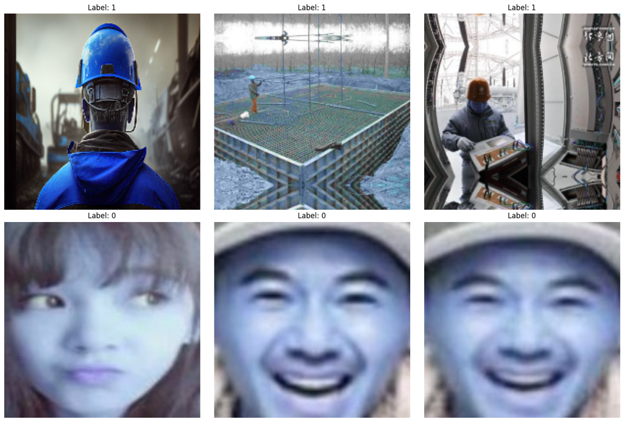

```python
# Get unique labels
unique_labels = labels['Label'].unique()

plt.figure(figsize=(15, 10))

# Loop through each unique label
for i, label_name in enumerate(unique_labels):
    # Get indices of images for the current label
    indices = np.where(labels['Label'] == label_name)[0]

    # Select 3 random indices from the current label
    random_indices = random.sample(list(indices), 3)

    # Plot the images
    for j, idx in enumerate(random_indices):
        plt.subplot(len(unique_labels), 3, i * 3 + j + 1)
        plt.imshow(images[idx])
        plt.title(f"Label: {label_name}")
        plt.axis('off')

plt.tight_layout()
plt.show()
```

## Checking for class imbalance

```
Label
0    320
1    311
Name: count, dtype: int64
```

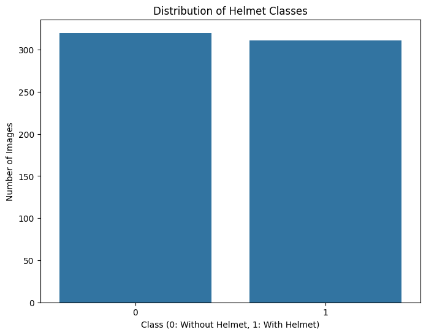

```python
label_counts = labels['Label'].value_counts()
print(label_counts)

plt.figure(figsize=(8, 6))
sns.barplot(x=label_counts.index, y=label_counts.values)
plt.title('Distribution of Helmet Classes')
plt.xlabel('Class (0: Without Helmet, 1: With Helmet)')
plt.ylabel('Number of Images')
plt.show()
```

# **Data Preprocessing**

## Converting images to grayscale

```python
grayscale_images = []
for img in images:
    gray_img = cv2.cvtColor(img, cv2.COLOR_RGB2GRAY)
    grayscale_images.append(gray_img)

images = np.array(grayscale_images)

print("Shape of grayscale images:", images.shape)
```

```
Shape of grayscale images: (631, 200, 200)
```

### Splitting the dataset

```python
# Reshape images to add a channel dimension for grayscale if it's not present
if images.ndim == 3:
    images = np.expand_dims(images, axis=-1)

# Split the data into training (70%) and temporary (30%) sets
X_train, X_temp, y_train, y_temp = train_test_split(images, labels, test_size=0.3, random_state=42, stratify=labels)

# Split the temporary data into validation (15%) and test (15%) sets
X_val, X_test, y_val, y_test = train_test_split(X_temp, y_temp, test_size=0.5, random_state=42, stratify=y_temp)

print(f"X_train shape: {X_train.shape}")
print(f"y_train shape: {y_train.shape}")
print(f"X_val shape: {X_val.shape}")
print(f"y_val shape: {y_val.shape}")
print(f"X_test shape: {X_test.shape}")
print(f"y_test shape: {y_test.shape}")
```

```
X_train shape: (441, 200, 200, 1)
y_train shape: (441, 1)
X_val shape: (95, 200, 200, 1)
y_val shape: (95, 1)
X_test shape: (95, 200, 200, 1)
y_test shape: (95, 1)
```

### Data Normalization

```python
X_train = X_train / 255.0
X_val = X_val / 255.0
X_test = X_test / 255.0

print(f"X_train min value: {X_train.min()}, max value: {X_train.max()}")
print(f"X_val min value: {X_val.min()}, max value: {X_val.max()}")
print(f"X_test min value: {X_test.min()}, max value: {X_test.max()}")
```

```
X_train min value: 0.0, max value: 1.0
X_val min value: 0.0, max value: 1.0
X_test min value: 0.0, max value: 1.0
```

# **Model Building**

## Model Evaluation Criterion

## Utility Functions

```python
# defining a function to compute different metrics to check performance of a classification model built using statsmodels
def model_performance_classification(model, predictors, target):
    """
    Function to compute different metrics to check classification model performance

    model: classifier
    predictors: independent variables
    target: dependent variable
    """

    # checking which probabilities are greater than threshold
    pred = model.predict(predictors).reshape(-1)>0.5

    target = target.to_numpy().reshape(-1)


    acc = accuracy_score(target, pred)  # to compute Accuracy
    recall = recall_score(target, pred, average='weighted')  # to compute Recall
    precision = precision_score(target, pred, average='weighted')  # to compute Precision
    f1 = f1_score(target, pred, average='weighted')  # to compute F1-score

    # creating a dataframe of metrics
    df_perf = pd.DataFrame({"Accuracy": acc, "Recall": recall, "Precision": precision, "F1 Score": f1,},index=[0],)

    return df_perf
```

```python
def plot_confusion_matrix(model,predictors,target,ml=False):
    """
    Function to plot the confusion matrix

    model: classifier
    predictors: independent variables
    target: dependent variable
    ml: To specify if the model used is an sklearn ML model or not (True means ML model)
    """

    # checking which probabilities are greater than threshold
    pred = model.predict(predictors).reshape(-1)>0.5

    target = target.to_numpy().reshape(-1)

    # Plotting the Confusion Matrix using confusion matrix() function which is also predefined tensorflow module
    confusion_matrix = tf.math.confusion_matrix(target,pred)
    f, ax = plt.subplots(figsize=(10, 8))
    sns.heatmap(
        confusion_matrix,
        annot=True,
        linewidths=.4,
        fmt="d",
        square=True,
        ax=ax
    )
    plt.show()
```

## Model 1: Simple Convolutional Neural Network (CNN)

```python
model1 = Sequential([
    Conv2D(32, (3, 3), activation='relu', input_shape=(200, 200, 1)),
    MaxPooling2D((2, 2)),
    Conv2D(64, (3, 3), activation='relu'),
    MaxPooling2D((2, 2)),
    Conv2D(128, (3, 3), activation='relu'),
    MaxPooling2D((2, 2)),
    Flatten(),
    Dense(128, activation='relu'),
    Dense(1, activation='sigmoid') # Sigmoid for binary classification
])

model1.compile(optimizer='adam', loss='binary_crossentropy', metrics=['accuracy'])

history1 = model1.fit(X_train, y_train, epochs=10, validation_data=(X_val, y_val), verbose=2)
```

```
14/14 - 12s - 890ms/step - accuracy: 0.5760 - loss: 0.7337 - val_accuracy: 0.8421 - val_loss: 0.3685
14/14 - 1s - 44ms/step - accuracy: 0.9569 - loss: 0.1778 - val_accuracy: 0.9684 - val_loss: 0.0923
14/14 - 1s - 43ms/step - accuracy: 0.9683 - loss: 0.0852 - val_accuracy: 0.9789 - val_loss: 0.2301
14/14 - 1s - 46ms/step - accuracy: 0.9864 - loss: 0.0458 - val_accuracy: 0.9579 - val_loss: 0.0986
14/14 - 1s - 46ms/step - accuracy: 0.9932 - loss: 0.0193 - val_accuracy: 0.9895 - val_loss: 0.2540
14/14 - 1s - 46ms/step - accuracy: 1.0000 - loss: 0.0026 - val_accuracy: 0.9895 - val_loss: 0.1654
14/14 - 1s - 53ms/step - accuracy: 1.0000 - loss: 4.8319e-04 - val_accuracy: 0.9895 - val_loss: 0.1404
14/14 - 1s - 46ms/step - accuracy: 1.0000 - loss: 2.4225e-04 - val_accuracy: 0.9895 - val_loss: 0.1364
14/14 - 1s - 43ms/step - accuracy: 1.0000 - loss: 1.7432e-04 - val_accuracy: 0.9895 - val_loss: 0.1395
14/14 - 1s - 44ms/step - accuracy: 1.0000 - loss: 1.3429e-04 - val_accuracy: 0.9895 - val_loss: 0.1432
```

### Vizualizing the predictions

```
Model 1 Test Performance:
3/3 ━━━━━━━━━━━━━━━━━━━━ 2s 463ms/step
   Accuracy  Recall  Precision  F1 Score
0       1.0     1.0        1.0       1.0

Confusion Matrix for Model 1:
3/3 ━━━━━━━━━━━━━━━━━━━━ 0s 23ms/step
```

```
3/3 ━━━━━━━━━━━━━━━━━━━━ 0s 20ms/step
```

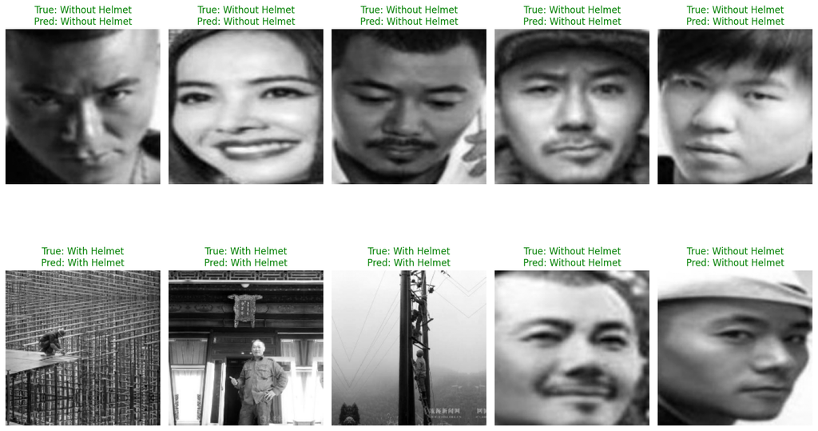

```python
# Evaluate model performance on the test set
print("Model 1 Test Performance:")
performance_df1 = model_performance_classification(model1, X_test, y_test)
print(performance_df1)

# Plot confusion matrix
print("\nConfusion Matrix for Model 1:")
plot_confusion_matrix(model1, X_test, y_test)

# Visualize some predictions
num_display = 10 # Number of images to display
random_indices = np.random.choice(len(X_test), num_display, replace=False)

predictions = (model1.predict(X_test) > 0.5).astype(int)

plt.figure(figsize=(15, 10))
for i, idx in enumerate(random_indices):
    plt.subplot(2, 5, i + 1) # 2 rows, 5 columns
    plt.imshow(X_test[idx].reshape(200, 200), cmap='gray')
    true_label = 'With Helmet' if y_test.iloc[idx].values[0] == 1 else 'Without Helmet'
    predicted_label = 'With Helmet' if predictions[idx][0] == 1 else 'Without Helmet'
    color = 'green' if true_label == predicted_label else 'red'
    plt.title(f"True: {true_label}\nPred: {predicted_label}", color=color)
    plt.axis('off')

plt.tight_layout()
plt.show()
```

[output not shown]

## Model 2: (VGG-16 (Base))

```python
from tensorflow.keras.applications import VGG16
from tensorflow.keras.models import Model
from tensorflow.keras.layers import Input, Lambda, Dense, Flatten
from tensorflow.keras.optimizers import Adam

# Define input shape for grayscale images
input_shape = (200, 200, 1)

# Create an input layer with the grayscale shape
input_tensor = Input(shape=input_shape)

# Convert grayscale to 3 channels (required by VGG16)
x = Lambda(lambda x: tf.image.grayscale_to_rgb(x), output_shape=(200, 200, 3))(input_tensor)

# Load VGG16 base model, excluding the top (fully connected) layers
vgg_base = VGG16(weights='imagenet', include_top=False, input_tensor=x)

# Freeze the layers of the VGG16 base model
for layer in vgg_base.layers:
    layer.trainable = False

# Add custom classification head on top of VGG16 base
x = Flatten()(vgg_base.output)
x = Dense(128, activation='relu')(x)
output_tensor = Dense(1, activation='sigmoid')(x)

# Create the full model
model2 = Model(inputs=input_tensor, outputs=output_tensor)

# Compile the model
model2.compile(optimizer=Adam(learning_rate=0.001), loss='binary_crossentropy', metrics=['accuracy'])

# Display model summary
model2.summary()

# Train the model
history2 = model2.fit(X_train, y_train, epochs=10, validation_data=(X_val, y_val), verbose=2)
```

```
Downloading data from https://storage.googleapis.com/tensorflow/keras-applications/vgg16/vgg16_weights_tf_dim_ordering_tf_kernels_notop.h5
58889256/58889256 ━━━━━━━━━━━━━━━━━━━━ 4s 0us/step
```

```
Model: "functional_1"
```

```
┏━━━━━━━━━━━━━━━━━━━━━━━━━━━━━━━━━┳━━━━━━━━━━━━━━━━━━━━━━━━┳━━━━━━━━━━━━━━━┓
┃ Layer (type)                    ┃ Output Shape           ┃       Param # ┃
┡━━━━━━━━━━━━━━━━━━━━━━━━━━━━━━━━━╇━━━━━━━━━━━━━━━━━━━━━━━━╇━━━━━━━━━━━━━━━┩
│ input_layer_1 (InputLayer)      │ (None, 200, 200, 1)    │             0 │
├─────────────────────────────────┼────────────────────────┼───────────────┤
│ lambda (Lambda)                 │ (None, 200, 200, 3)    │             0 │
├─────────────────────────────────┼────────────────────────┼───────────────┤
│ block1_conv1 (Conv2D)           │ (None, 200, 200, 64)   │         1,792 │
├─────────────────────────────────┼────────────────────────┼───────────────┤
│ block1_conv2 (Conv2D)           │ (None, 200, 200, 64)   │        36,928 │
├─────────────────────────────────┼────────────────────────┼───────────────┤
│ block1_pool (MaxPooling2D)      │ (None, 100, 100, 64)   │             0 │
├─────────────────────────────────┼────────────────────────┼───────────────┤
│ block2_conv1 (Conv2D)           │ (None, 100, 100, 128)  │        73,856 │
├─────────────────────────────────┼────────────────────────┼───────────────┤
│ block2_conv2 (Conv2D)           │ (None, 100, 100, 128)  │       147,584 │
├─────────────────────────────────┼────────────────────────┼───────────────┤
│ block2_pool (MaxPooling2D)      │ (None, 50, 50, 128)    │             0 │
├─────────────────────────────────┼────────────────────────┼───────────────┤
│ block3_conv1 (Conv2D)           │ (None, 50, 50, 256)    │       295,168 │
├─────────────────────────────────┼────────────────────────┼───────────────┤
│ block3_conv2 (Conv2D)           │ (None, 50, 50, 256)    │       590,080 │
├─────────────────────────────────┼────────────────────────┼───────────────┤
│ block3_conv3 (Conv2D)           │ (None, 50, 50, 256)    │       590,080 │
├─────────────────────────────────┼────────────────────────┼───────────────┤
│ block3_pool (MaxPooling2D)      │ (None, 25, 25, 256)    │             0 │
├─────────────────────────────────┼────────────────────────┼───────────────┤
│ block4_conv1 (Conv2D)           │ (None, 25, 25, 512)    │     1,180,160 │
├─────────────────────────────────┼────────────────────────┼───────────────┤
│ block4_conv2 (Conv2D)           │ (None, 25, 25, 512)    │     2,359,808 │
├─────────────────────────────────┼────────────────────────┼───────────────┤
│ block4_conv3 (Conv2D)           │ (None, 25, 25, 512)    │     2,359,808 │
├─────────────────────────────────┼────────────────────────┼───────────────┤
│ block4_pool (MaxPooling2D)      │ (None, 12, 12, 512)    │             0 │
├─────────────────────────────────┼────────────────────────┼───────────────┤
│ block5_conv1 (Conv2D)           │ (None, 12, 12, 512)    │     2,359,808 │
├─────────────────────────────────┼────────────────────────┼───────────────┤
│ block5_conv2 (Conv2D)           │ (None, 12, 12, 512)    │     2,359,808 │
├─────────────────────────────────┼────────────────────────┼───────────────┤
│ block5_conv3 (Conv2D)           │ (None, 12, 12, 512)    │     2,359,808 │
├─────────────────────────────────┼────────────────────────┼───────────────┤
│ block5_pool (MaxPooling2D)      │ (None, 6, 6, 512)      │             0 │
├─────────────────────────────────┼────────────────────────┼───────────────┤
│ flatten_1 (Flatten)             │ (None, 18432)          │             0 │
├─────────────────────────────────┼────────────────────────┼───────────────┤
│ dense_2 (Dense)                 │ (None, 128)            │     2,359,424 │
├─────────────────────────────────┼────────────────────────┼───────────────┤
│ dense_3 (Dense)                 │ (None, 1)              │           129 │
└─────────────────────────────────┴────────────────────────┴───────────────┘
```

```
 Total params: 17,074,241 (65.13 MB)
```

```
 Trainable params: 2,359,553 (9.00 MB)
```

```
 Non-trainable params: 14,714,688 (56.13 MB)
```

```
14/14 - 34s - 2s/step - accuracy: 0.9161 - loss: 0.1905 - val_accuracy: 1.0000 - val_loss: 0.0010
14/14 - 2s - 175ms/step - accuracy: 1.0000 - loss: 9.3858e-05 - val_accuracy: 1.0000 - val_loss: 0.0061
14/14 - 2s - 176ms/step - accuracy: 1.0000 - loss: 2.6794e-06 - val_accuracy: 0.9895 - val_loss: 0.0129
14/14 - 2s - 178ms/step - accuracy: 1.0000 - loss: 3.4435e-06 - val_accuracy: 0.9895 - val_loss: 0.0140
14/14 - 3s - 179ms/step - accuracy: 1.0000 - loss: 3.1487e-06 - val_accuracy: 0.9895 - val_loss: 0.0128
14/14 - 2s - 177ms/step - accuracy: 1.0000 - loss: 2.5461e-06 - val_accuracy: 0.9895 - val_loss: 0.0113
14/14 - 2s - 177ms/step - accuracy: 1.0000 - loss: 2.0559e-06 - val_accuracy: 0.9895 - val_loss: 0.0100
14/14 - 2s - 177ms/step - accuracy: 1.0000 - loss: 1.7109e-06 - val_accuracy: 0.9895 - val_loss: 0.0090
14/14 - 3s - 180ms/step - accuracy: 1.0000 - loss: 1.4686e-06 - val_accuracy: 1.0000 - val_loss: 0.0082
14/14 - 3s - 180ms/step - accuracy: 1.0000 - loss: 1.2929e-06 - val_accuracy: 1.0000 - val_loss: 0.0075
```

### Visualizing the prediction:

```
Model 2 Test Performance:
3/3 ━━━━━━━━━━━━━━━━━━━━ 3s 679ms/step
   Accuracy  Recall  Precision  F1 Score
0       1.0     1.0        1.0       1.0

Confusion Matrix for Model 2:
3/3 ━━━━━━━━━━━━━━━━━━━━ 1s 151ms/step
```

```
3/3 ━━━━━━━━━━━━━━━━━━━━ 0s 149ms/step
```

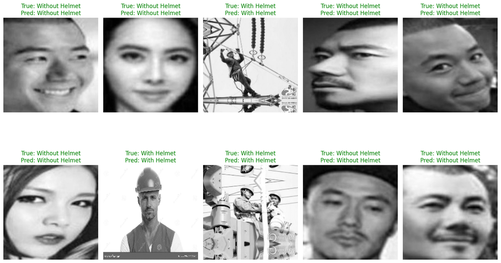

```python
# Evaluate model performance on the test set
print("Model 2 Test Performance:")
performance_df2 = model_performance_classification(model2, X_test, y_test)
print(performance_df2)

# Plot confusion matrix
print("\nConfusion Matrix for Model 2:")
plot_confusion_matrix(model2, X_test, y_test)

# Visualize some predictions
num_display = 10 # Number of images to display
random_indices = np.random.choice(len(X_test), num_display, replace=False)

predictions = (model2.predict(X_test) > 0.5).astype(int)

plt.figure(figsize=(15, 10))
for i, idx in enumerate(random_indices):
    plt.subplot(2, 5, i + 1) # 2 rows, 5 columns
    plt.imshow(X_test[idx].reshape(200, 200), cmap='gray')
    true_label = 'With Helmet' if y_test.iloc[idx].values[0] == 1 else 'Without Helmet'
    predicted_label = 'With Helmet' if predictions[idx][0] == 1 else 'Without Helmet'
    color = 'green' if true_label == predicted_label else 'red'
    plt.title(f"True: {true_label}\nPred: {predicted_label}", color=color)
    plt.axis('off')

plt.tight_layout()
plt.show()
```

[output not shown]

## Model 3: (VGG-16 (Base + FFNN))

```python
# Define input shape for grayscale images
input_shape = (200, 200, 1)

# Create an input layer with the grayscale shape
input_tensor = Input(shape=input_shape)

# Convert grayscale to 3 channels (required by VGG16)
x = Lambda(lambda x: tf.image.grayscale_to_rgb(x), output_shape=(200, 200, 3))(input_tensor)

# Load VGG16 base model, excluding the top (fully connected) layers
vgg_base = VGG16(weights='imagenet', include_top=False, input_tensor=x)

# Freeze the layers of the VGG16 base model
for layer in vgg_base.layers:
    layer.trainable = False

# Add custom classification head on top of VGG16 base
x = Flatten()(vgg_base.output)
x = Dense(256, activation='relu')(x)  # Increased units
x = Dropout(0.5)(x)                   # Added dropout for regularization
x = Dense(128, activation='relu')(x)
output_tensor = Dense(1, activation='sigmoid')(x)

# Create the full model
model3 = Model(inputs=input_tensor, outputs=output_tensor)

# Compile the model
model3.compile(optimizer=Adam(learning_rate=0.001), loss='binary_crossentropy', metrics=['accuracy'])

# Display model summary
model3.summary()

# Train the model
history3 = model3.fit(X_train, y_train, epochs=10, validation_data=(X_val, y_val), verbose=2)
```

```
Model: "functional_2"
```

```
┏━━━━━━━━━━━━━━━━━━━━━━━━━━━━━━━━━┳━━━━━━━━━━━━━━━━━━━━━━━━┳━━━━━━━━━━━━━━━┓
┃ Layer (type)                    ┃ Output Shape           ┃       Param # ┃
┡━━━━━━━━━━━━━━━━━━━━━━━━━━━━━━━━━╇━━━━━━━━━━━━━━━━━━━━━━━━╇━━━━━━━━━━━━━━━┩
│ input_layer_2 (InputLayer)      │ (None, 200, 200, 1)    │             0 │
├─────────────────────────────────┼────────────────────────┼───────────────┤
│ lambda_1 (Lambda)               │ (None, 200, 200, 3)    │             0 │
├─────────────────────────────────┼────────────────────────┼───────────────┤
│ block1_conv1 (Conv2D)           │ (None, 200, 200, 64)   │         1,792 │
├─────────────────────────────────┼────────────────────────┼───────────────┤
│ block1_conv2 (Conv2D)           │ (None, 200, 200, 64)   │        36,928 │
├─────────────────────────────────┼────────────────────────┼───────────────┤
│ block1_pool (MaxPooling2D)      │ (None, 100, 100, 64)   │             0 │
├─────────────────────────────────┼────────────────────────┼───────────────┤
│ block2_conv1 (Conv2D)           │ (None, 100, 100, 128)  │        73,856 │
├─────────────────────────────────┼────────────────────────┼───────────────┤
│ block2_conv2 (Conv2D)           │ (None, 100, 100, 128)  │       147,584 │
├─────────────────────────────────┼────────────────────────┼───────────────┤
│ block2_pool (MaxPooling2D)      │ (None, 50, 50, 128)    │             0 │
├─────────────────────────────────┼────────────────────────┼───────────────┤
│ block3_conv1 (Conv2D)           │ (None, 50, 50, 256)    │       295,168 │
├─────────────────────────────────┼────────────────────────┼───────────────┤
│ block3_conv2 (Conv2D)           │ (None, 50, 50, 256)    │       590,080 │
├─────────────────────────────────┼────────────────────────┼───────────────┤
│ block3_conv3 (Conv2D)           │ (None, 50, 50, 256)    │       590,080 │
├─────────────────────────────────┼────────────────────────┼───────────────┤
│ block3_pool (MaxPooling2D)      │ (None, 25, 25, 256)    │             0 │
├─────────────────────────────────┼────────────────────────┼───────────────┤
│ block4_conv1 (Conv2D)           │ (None, 25, 25, 512)    │     1,180,160 │
├─────────────────────────────────┼────────────────────────┼───────────────┤
│ block4_conv2 (Conv2D)           │ (None, 25, 25, 512)    │     2,359,808 │
├─────────────────────────────────┼────────────────────────┼───────────────┤
│ block4_conv3 (Conv2D)           │ (None, 25, 25, 512)    │     2,359,808 │
├─────────────────────────────────┼────────────────────────┼───────────────┤
│ block4_pool (MaxPooling2D)      │ (None, 12, 12, 512)    │             0 │
├─────────────────────────────────┼────────────────────────┼───────────────┤
│ block5_conv1 (Conv2D)           │ (None, 12, 12, 512)    │     2,359,808 │
├─────────────────────────────────┼────────────────────────┼───────────────┤
│ block5_conv2 (Conv2D)           │ (None, 12, 12, 512)    │     2,359,808 │
├─────────────────────────────────┼────────────────────────┼───────────────┤
│ block5_conv3 (Conv2D)           │ (None, 12, 12, 512)    │     2,359,808 │
├─────────────────────────────────┼────────────────────────┼───────────────┤
│ block5_pool (MaxPooling2D)      │ (None, 6, 6, 512)      │             0 │
├─────────────────────────────────┼────────────────────────┼───────────────┤
│ flatten_2 (Flatten)             │ (None, 18432)          │             0 │
├─────────────────────────────────┼────────────────────────┼───────────────┤
│ dense_4 (Dense)                 │ (None, 256)            │     4,718,848 │
├─────────────────────────────────┼────────────────────────┼───────────────┤
│ dropout (Dropout)               │ (None, 256)            │             0 │
├─────────────────────────────────┼────────────────────────┼───────────────┤
│ dense_5 (Dense)                 │ (None, 128)            │        32,896 │
├─────────────────────────────────┼────────────────────────┼───────────────┤
│ dense_6 (Dense)                 │ (None, 1)              │           129 │
└─────────────────────────────────┴────────────────────────┴───────────────┘
```

```
 Total params: 19,466,561 (74.26 MB)
```

```
 Trainable params: 4,751,873 (18.13 MB)
```

```
 Non-trainable params: 14,714,688 (56.13 MB)
```

```
14/14 - 10s - 704ms/step - accuracy: 0.9138 - loss: 0.1740 - val_accuracy: 0.9895 - val_loss: 0.0148
14/14 - 2s - 169ms/step - accuracy: 0.9955 - loss: 0.0060 - val_accuracy: 1.0000 - val_loss: 0.0011
14/14 - 2s - 171ms/step - accuracy: 1.0000 - loss: 0.0015 - val_accuracy: 1.0000 - val_loss: 0.0022
14/14 - 2s - 172ms/step - accuracy: 1.0000 - loss: 1.3195e-04 - val_accuracy: 1.0000 - val_loss: 0.0013
14/14 - 2s - 170ms/step - accuracy: 1.0000 - loss: 5.2294e-04 - val_accuracy: 1.0000 - val_loss: 0.0042
14/14 - 2s - 170ms/step - accuracy: 1.0000 - loss: 1.7112e-05 - val_accuracy: 0.9895 - val_loss: 0.0100
14/14 - 2s - 171ms/step - accuracy: 1.0000 - loss: 1.9891e-05 - val_accuracy: 0.9895 - val_loss: 0.0118
14/14 - 2s - 171ms/step - accuracy: 1.0000 - loss: 1.1764e-05 - val_accuracy: 0.9895 - val_loss: 0.0097
14/14 - 3s - 179ms/step - accuracy: 1.0000 - loss: 5.7561e-05 - val_accuracy: 1.0000 - val_loss: 0.0054
14/14 - 3s - 192ms/step - accuracy: 1.0000 - loss: 3.9241e-06 - val_accuracy: 1.0000 - val_loss: 0.0032
```

#### Visualizing the predictions

```
Model 3 Test Performance:
3/3 ━━━━━━━━━━━━━━━━━━━━ 2s 476ms/step
   Accuracy  Recall  Precision  F1 Score
0       1.0     1.0        1.0       1.0

Confusion Matrix for Model 3:
3/3 ━━━━━━━━━━━━━━━━━━━━ 0s 145ms/step
```

```
3/3 ━━━━━━━━━━━━━━━━━━━━ 0s 145ms/step
```

[figure not shown]

```python
# Evaluate model performance on the test set
print("Model 3 Test Performance:")
performance_df3 = model_performance_classification(model3, X_test, y_test)
print(performance_df3)

# Plot confusion matrix
print("\nConfusion Matrix for Model 3:")
plot_confusion_matrix(model3, X_test, y_test)

# Visualize some predictions
num_display = 10 # Number of images to display
random_indices = np.random.choice(len(X_test), num_display, replace=False)

predictions = (model3.predict(X_test) > 0.5).astype(int)

plt.figure(figsize=(15, 10))
for i, idx in enumerate(random_indices):
    plt.subplot(2, 5, i + 1) # 2 rows, 5 columns
    plt.imshow(X_test[idx].reshape(200, 200), cmap='gray')
    true_label = 'With Helmet' if y_test.iloc[idx].values[0] == 1 else 'Without Helmet'
    predicted_label = 'With Helmet' if predictions[idx][0] == 1 else 'Without Helmet'
    color = 'green' if true_label == predicted_label else 'red'
    plt.title(f"True: {true_label}\nPred: {predicted_label}", color=color)
    plt.axis('off')

plt.tight_layout()
plt.show()
```

[output not shown]

## Model 4: (VGG-16 (Base + FFNN + Data Augmentation)

- In most of the real-world case studies, it is challenging to acquire a large number of images and then train CNNs.
- To overcome this problem, one approach we might consider is **Data Augmentation**.
- CNNs have the property of **translational invariance**, which means they can recognise an object even if its appearance shifts translationally in some way. - Taking this attribute into account, we can augment the images using the techniques listed below
  - Horizontal Flip (should be set to True/False)
  - Vertical Flip (should be set to True/False)
  - Height Shift (should be between 0 and 1)
  - Width Shift (should be between 0 and 1)
  - Rotation (should be between 0 and 180)
  - Shear (should be between 0 and 1)
  - Zoom (should be between 0 and 1) etc.

Remember, **data augmentation should not be used in the validation/test data set**.

```python
# Initialize ImageDataGenerator for data augmentation
datagen = ImageDataGenerator(
    rotation_range=20,
    width_shift_range=0.2,
    height_shift_range=0.2,
    shear_range=0.2,
    zoom_range=0.2,
    horizontal_flip=True,
    fill_mode='nearest'
)

# Fit the data augmentation generator on the training data
datagen.fit(X_train)

# Define input shape for grayscale images
input_shape = (200, 200, 1)

# Create an input layer with the grayscale shape
input_tensor = Input(shape=input_shape)

# Convert grayscale to 3 channels (required by VGG16)
x = Lambda(lambda x: tf.image.grayscale_to_rgb(x), output_shape=(200, 200, 3))(input_tensor)

# Load VGG16 base model, excluding the top (fully connected) layers
vgg_base = VGG16(weights='imagenet', include_top=False, input_tensor=x)

# Freeze the layers of the VGG16 base model
for layer in vgg_base.layers:
    layer.trainable = False

# Add custom classification head on top of VGG16 base
x = Flatten()(vgg_base.output)
x = Dense(256, activation='relu')(x)  # Increased units
x = Dropout(0.5)(x)                   # Added dropout for regularization
x = Dense(128, activation='relu')(x)
output_tensor = Dense(1, activation='sigmoid')(x)

# Create the full model
model4 = Model(inputs=input_tensor, outputs=output_tensor)

# Compile the model
model4.compile(optimizer=Adam(learning_rate=0.001), loss='binary_crossentropy', metrics=['accuracy'])

# Display model summary
model4.summary()

# Train the model with data augmentation
history4 = model4.fit(datagen.flow(X_train, y_train, batch_size=32), epochs=10, validation_data=(X_val, y_val), verbose=2)
```

```
Model: "functional_3"
```

```
┏━━━━━━━━━━━━━━━━━━━━━━━━━━━━━━━━━┳━━━━━━━━━━━━━━━━━━━━━━━━┳━━━━━━━━━━━━━━━┓
┃ Layer (type)                    ┃ Output Shape           ┃       Param # ┃
┡━━━━━━━━━━━━━━━━━━━━━━━━━━━━━━━━━╇━━━━━━━━━━━━━━━━━━━━━━━━╇━━━━━━━━━━━━━━━┩
│ input_layer_3 (InputLayer)      │ (None, 200, 200, 1)    │             0 │
├─────────────────────────────────┼────────────────────────┼───────────────┤
│ lambda_2 (Lambda)               │ (None, 200, 200, 3)    │             0 │
├─────────────────────────────────┼────────────────────────┼───────────────┤
│ block1_conv1 (Conv2D)           │ (None, 200, 200, 64)   │         1,792 │
├─────────────────────────────────┼────────────────────────┼───────────────┤
│ block1_conv2 (Conv2D)           │ (None, 200, 200, 64)   │        36,928 │
├─────────────────────────────────┼────────────────────────┼───────────────┤
│ block1_pool (MaxPooling2D)      │ (None, 100, 100, 64)   │             0 │
├─────────────────────────────────┼────────────────────────┼───────────────┤
│ block2_conv1 (Conv2D)           │ (None, 100, 100, 128)  │        73,856 │
├─────────────────────────────────┼────────────────────────┼───────────────┤
│ block2_conv2 (Conv2D)           │ (None, 100, 100, 128)  │       147,584 │
├─────────────────────────────────┼────────────────────────┼───────────────┤
│ block2_pool (MaxPooling2D)      │ (None, 50, 50, 128)    │             0 │
├─────────────────────────────────┼────────────────────────┼───────────────┤
│ block3_conv1 (Conv2D)           │ (None, 50, 50, 256)    │       295,168 │
├─────────────────────────────────┼────────────────────────┼───────────────┤
│ block3_conv2 (Conv2D)           │ (None, 50, 50, 256)    │       590,080 │
├─────────────────────────────────┼────────────────────────┼───────────────┤
│ block3_conv3 (Conv2D)           │ (None, 50, 50, 256)    │       590,080 │
├─────────────────────────────────┼────────────────────────┼───────────────┤
│ block3_pool (MaxPooling2D)      │ (None, 25, 25, 256)    │             0 │
├─────────────────────────────────┼────────────────────────┼───────────────┤
│ block4_conv1 (Conv2D)           │ (None, 25, 25, 512)    │     1,180,160 │
├─────────────────────────────────┼────────────────────────┼───────────────┤
│ block4_conv2 (Conv2D)           │ (None, 25, 25, 512)    │     2,359,808 │
├─────────────────────────────────┼────────────────────────┼───────────────┤
│ block4_conv3 (Conv2D)           │ (None, 25, 25, 512)    │     2,359,808 │
├─────────────────────────────────┼────────────────────────┼───────────────┤
│ block4_pool (MaxPooling2D)      │ (None, 12, 12, 512)    │             0 │
├─────────────────────────────────┼────────────────────────┼───────────────┤
│ block5_conv1 (Conv2D)           │ (None, 12, 12, 512)    │     2,359,808 │
├─────────────────────────────────┼────────────────────────┼───────────────┤
│ block5_conv2 (Conv2D)           │ (None, 12, 12, 512)    │     2,359,808 │
├─────────────────────────────────┼────────────────────────┼───────────────┤
│ block5_conv3 (Conv2D)           │ (None, 12, 12, 512)    │     2,359,808 │
├─────────────────────────────────┼────────────────────────┼───────────────┤
│ block5_pool (MaxPooling2D)      │ (None, 6, 6, 512)      │             0 │
├─────────────────────────────────┼────────────────────────┼───────────────┤
│ flatten_3 (Flatten)             │ (None, 18432)          │             0 │
├─────────────────────────────────┼────────────────────────┼───────────────┤
│ dense_7 (Dense)                 │ (None, 256)            │     4,718,848 │
├─────────────────────────────────┼────────────────────────┼───────────────┤
│ dropout_1 (Dropout)             │ (None, 256)            │             0 │
├─────────────────────────────────┼────────────────────────┼───────────────┤
│ dense_8 (Dense)                 │ (None, 128)            │        32,896 │
├─────────────────────────────────┼────────────────────────┼───────────────┤
│ dense_9 (Dense)                 │ (None, 1)              │           129 │
└─────────────────────────────────┴────────────────────────┴───────────────┘
```

```
 Total params: 19,466,561 (74.26 MB)
```

```
 Trainable params: 4,751,873 (18.13 MB)
```

```
 Non-trainable params: 14,714,688 (56.13 MB)
```

```
14/14 - 11s - 771ms/step - accuracy: 0.8231 - loss: 0.3966 - val_accuracy: 1.0000 - val_loss: 0.0052
14/14 - 3s - 181ms/step - accuracy: 0.9955 - loss: 0.0160 - val_accuracy: 1.0000 - val_loss: 0.0028
14/14 - 3s - 181ms/step - accuracy: 1.0000 - loss: 0.0026 - val_accuracy: 1.0000 - val_loss: 0.0012
14/14 - 3s - 179ms/step - accuracy: 1.0000 - loss: 0.0017 - val_accuracy: 0.9895 - val_loss: 0.0079
14/14 - 3s - 189ms/step - accuracy: 1.0000 - loss: 0.0044 - val_accuracy: 1.0000 - val_loss: 5.3550e-04
14/14 - 3s - 202ms/step - accuracy: 1.0000 - loss: 0.0011 - val_accuracy: 1.0000 - val_loss: 8.3093e-04
14/14 - 3s - 180ms/step - accuracy: 1.0000 - loss: 4.3207e-04 - val_accuracy: 1.0000 - val_loss: 3.1530e-04
14/14 - 3s - 180ms/step - accuracy: 1.0000 - loss: 7.5454e-05 - val_accuracy: 1.0000 - val_loss: 9.0778e-04
14/14 - 3s - 181ms/step - accuracy: 0.9887 - loss: 0.0184 - val_accuracy: 1.0000 - val_loss: 0.0061
14/14 - 3s - 201ms/step - accuracy: 0.9977 - loss: 0.0085 - val_accuracy: 1.0000 - val_loss: 0.0019
```

#### Visualizing the predictions

```
Model 4 Test Performance:
3/3 ━━━━━━━━━━━━━━━━━━━━ 2s 464ms/step
   Accuracy  Recall  Precision  F1 Score
0       1.0     1.0        1.0       1.0

Confusion Matrix for Model 4:
3/3 ━━━━━━━━━━━━━━━━━━━━ 0s 145ms/step
```

```
3/3 ━━━━━━━━━━━━━━━━━━━━ 0s 145ms/step
```

[figure not shown]

```python
# Evaluate model performance on the test set
print("Model 4 Test Performance:")
performance_df4 = model_performance_classification(model4, X_test, y_test)
print(performance_df4)

# Plot confusion matrix
print("\nConfusion Matrix for Model 4:")
plot_confusion_matrix(model4, X_test, y_test)

# Visualize some predictions
num_display = 10 # Number of images to display
random_indices = np.random.choice(len(X_test), num_display, replace=False)

predictions = (model4.predict(X_test) > 0.5).astype(int)

plt.figure(figsize=(15, 10))
for i, idx in enumerate(random_indices):
    plt.subplot(2, 5, i + 1) # 2 rows, 5 columns
    plt.imshow(X_test[idx].reshape(200, 200), cmap='gray')
    true_label = 'With Helmet' if y_test.iloc[idx].values[0] == 1 else 'Without Helmet'
    predicted_label = 'With Helmet' if predictions[idx][0] == 1 else 'Without Helmet'
    color = 'green' if true_label == predicted_label else 'red'
    plt.title(f"True: {true_label}\nPred: {predicted_label}", color=color)
    plt.axis('off')

plt.tight_layout()
plt.show()
```

[output not shown]

# **Model Performance Comparison and Final Model Selection**

```python
performance_comparison = pd.concat([
    performance_df1.assign(Model='Model 1 (Simple CNN)'),
    performance_df2.assign(Model='Model 2 (VGG-16 Base)'),
    performance_df3.assign(Model='Model 3 (VGG-16 Base + FFNN)'),
    performance_df4.assign(Model='Model 4 (VGG-16 Base + FFNN + Data Augmentation)')
], ignore_index=True)

print("\n--- Model Performance Comparison ---")
print(performance_comparison.set_index('Model'))
```

```
--- Model Performance Comparison ---
                                                  Accuracy  Recall  Precision  \
Model
Model 1 (Simple CNN)                                   1.0     1.0        1.0
Model 2 (VGG-16 Base)                                  1.0     1.0        1.0
Model 3 (VGG-16 Base + FFNN)                           1.0     1.0        1.0
Model 4 (VGG-16 Base + FFNN + Data Augmentation)       1.0     1.0        1.0

                                                  F1 Score
Model
Model 1 (Simple CNN)                                   1.0
Model 2 (VGG-16 Base)                                  1.0
Model 3 (VGG-16 Base + FFNN)                           1.0
Model 4 (VGG-16 Base + FFNN + Data Augmentation)       1.0
```

## Test Performance

The actionable insights and recommendations section explains why I chose Model 4 as the model to complete this section

```
Model 4 Test Performance (Final Model Selection):
3/3 ━━━━━━━━━━━━━━━━━━━━ 1s 155ms/step
   Accuracy  Recall  Precision  F1 Score
0       1.0     1.0        1.0       1.0

Confusion Matrix for Model 4:
3/3 ━━━━━━━━━━━━━━━━━━━━ 0s 142ms/step
```

```
3/3 ━━━━━━━━━━━━━━━━━━━━ 0s 145ms/step
```

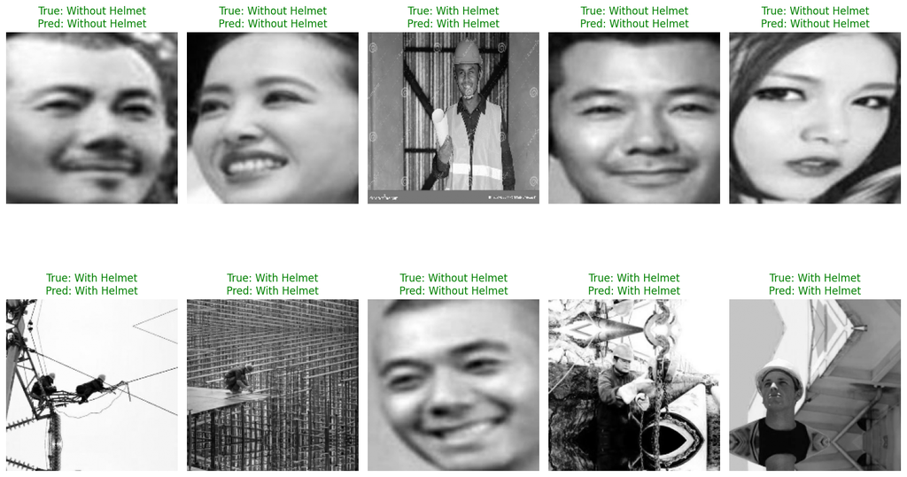

```python
# Evaluate Model 4 performance on the test set
print("Model 4 Test Performance (Final Model Selection):")
performance_final = model_performance_classification(model4, X_test, y_test)
print(performance_final)

# Plot confusion matrix for Model 4
print("\nConfusion Matrix for Model 4:")
plot_confusion_matrix(model4, X_test, y_test)

# Visualize some predictions for Model 4
num_display = 10 # Number of images to display
random_indices = np.random.choice(len(X_test), num_display, replace=False)

predictions = (model4.predict(X_test) > 0.5).astype(int)

plt.figure(figsize=(15, 10))
for i, idx in enumerate(random_indices):
    plt.subplot(2, 5, i + 1) # 2 rows, 5 columns
    plt.imshow(X_test[idx].reshape(200, 200), cmap='gray')
    true_label = 'With Helmet' if y_test.iloc[idx].values[0] == 1 else 'Without Helmet'
    predicted_label = 'With Helmet' if predictions[idx][0] == 1 else 'Without Helmet'
    color = 'green' if true_label == predicted_label else 'red'
    plt.title(f"True: {true_label}\nPred: {predicted_label}", color=color)
    plt.axis('off')

plt.tight_layout()
plt.show()
```

[output not shown]

# **Actionable Insights & Recommendations**

All four models—from the simple CNN to the VGG-16 based models with and without data augmentation—achieved perfect scores (100% Accuracy, Recall, Precision, and F1 Score) on the test set. This indicates that for this specific dataset, the task of classifying 'With Helmet' vs. 'Without Helmet' is highly separable and relatively easy for all the developed models.

Final Model Selection and Recommendations:

Given that all models performed perfectly on the test set, the choice of a 'final model' shifts from absolute performance to other practical considerations:

- Simplicity: Model 1 (Simple CNN) achieved the same perfect performance with the least complexity. It has fewer parameters and would generally be faster to train and deploy. In situations where multiple models achieve identical high performance, the simpler model is often preferred.
- Robustness and Generalization: While all models perform perfectly on the current test set, in real-world scenarios, data can be more varied and noisy. Data augmentation (as used in Model 4) helps a model learn more robust features and improve generalization to unseen, real-world images that might differ slightly from the training distribution. Therefore, for deployment in a real-world system where variations are expected, Model 4, despite its larger size, might offer better long-term reliability due to its enhanced generalization capabilities through data augmentation.
- Efficiency: The VGG-16 based models (Model 2, 3, and 4) are significantly larger due to the pre-trained convolutional base. If computational resources or inference speed are critical, Model 1 would be the most efficient choice.

Conclusion:

For this specific problem and dataset, the Simple CNN (Model 1) is the most efficient choice given its perfect performance and lower complexity. However, if the goal is to build a system that is robust against future, more diverse real-world conditions, Model 4 (VGG-16 Base + FFNN + Data Augmentation) would be the recommended choice due to the benefits of transfer learning and data augmentation, which promote better generalization.

To further evaluate the models, especially for real-world application, it would be beneficial to:

- Test with a larger, more diverse dataset from actual deployment scenarios.
- Analyze predictions on edge cases or images with challenging conditions (e.g., poor lighting, unusual angles).
- Consider model interpretability to understand why certain predictions are made.

Power Ahead!

```python
#@title Convert ipynb to HTML in Colab
# Upload ipynb
from google.colab import files
f = files.upload()

# Convert ipynb to html
import subprocess
file0 = list(f.keys())[0]
_ = subprocess.run(["pip", "install", "nbconvert"])
_ = subprocess.run(["jupyter", "nbconvert", file0, "--to", "html"])

# download the html
files.download(file0[:-5]+"html")
```